# Introduction

Project Zero is the flagship out-of-box demo for the SimpleLink SDK BLE Plugin. It showcases several functional features of the MSP432 + CC2650 BLE ecosystem and is easy to setup and configure. Several different hardware fusions are demonstrated such as dynamic LED control and push button interrupt monitoring. A data monitoring service is also demonstrated which showcases simple storage and streaming of binary data.

# Hardware Prerequisites

Project Zero code example requires the standard configuration of an [MSP-EXP432P401R](http://www.ti.com/tool/msp-exp432p401r) LaunchPad with an attached [BOOSTXL-CC2650](http://www.ti.com/tool/boostxl-cc2650ma) BoosterPack or [LAUNCHXL-CC2640R2](http://www.ti.com/tool/launchxl-cc2640r2) Launchpad. This hardware configuration is shown in the below image:

[figure not shown]

Alternatively, the CC2640R2 LaunchPad can be used in lieu of the CC2650 BoosterPack. In this case the CC2640R2 LaunchPad should be stacked on the MSP432 LaunchPad as seen below:

[figure not shown]

# Software Prerequisites

This code example has been tested with the tool and compiler versions listed in the Release Notes. For more information on how to import this project into your IDE workspace and build/run, please refer to the main user’s guide.

# Service/Profile Table

| **Purpose** | **UUID** | **Format** | **Properties** | **Profile Source** |
| --- | --- | --- | --- | --- |
| LED Color Control | F0001111-0451-4000-B000-000000000000 | Integer | Read/Write | led_service.c |
| S1 Button Status | F0001121-0451-4000-B000-000000000000 | Integer | Notification | button_service.c |
| S2 Button Status | F0001122-0451-4000-B000-000000000000 | Integer | Notification | button_service.c |
| Data String Storage | F0001131-0451-4000-B000-000000000000 | UTF-8 String | Read/Write | data_service.c |
| Data Stream | F0001132-0451-4000-B000-000000000000 | Integer | Notification/Write No Response | data_service.c |

# Usage

Once the Project Zero code example starts the output to the terminal will notify the user of the registering of callbacks and interrupts as seen below:

[figure not shown]

If this information fails to display, check your hardware configuration and make sure that the SNP image is programmed correctly on the CC2650 BoosterPack. Once started, advertising is enabled by default and there is no need to physically press a button on the LaunchPad in order to start BLE advertising. A Bluetooth device with the name of “Project Zero” should be advertised (note the navigation might be slightly different depending on your mobile application):

[figure not shown]

Connect to the device. After negotiation/handshakes you should be connected to the Project Zero device with various system information displayed:

[figure not shown]

Scrolling down, you should see a list of three services as well as their corresponding characteristics (described in detail below):

[figure not shown]

## LED Service (UUID: F0001110-0451-4000-B000-000000000000)

The LED service allows users to remotely control and manipulate the on-board tricolor LED of the LaunchPad. This LED is connected to the LED2 pin at the bottom of the MSP432 LaunchPad. The sole characteristic of the LED Service is a three byte hex string. This string equates to RGB values on the LED. The highest byte represents the red value, middle byte represents the green value, and lowest byte represents the blue value. By default, this value is set to 0x000000:

[figure not shown]

If this value was set to 0x0000FF, for example:

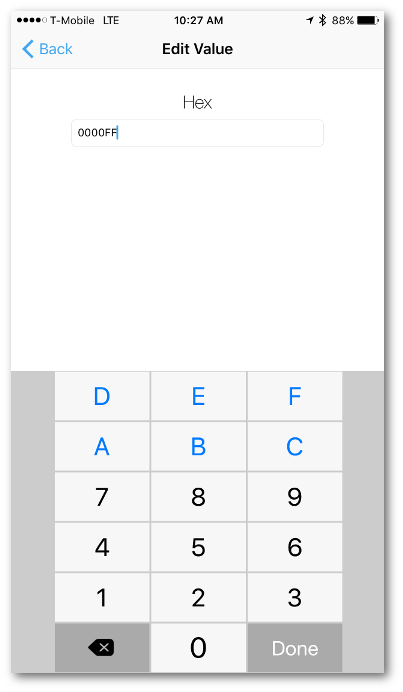

This would result in the LED on LED2 being set to blue:

[figure not shown]

Values can be combined in any fashion or manner to create any color combination that you want. A value of 0xFF00FF being written to the characteristic:

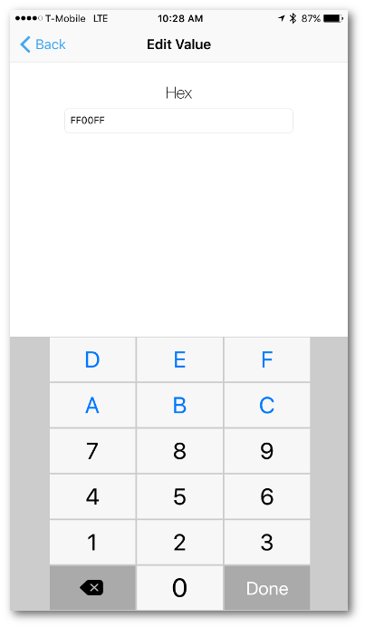

Would result in a purple color being shown on the LED (full blue plus full red):

[figure not shown]

## Button Service (UUID: F0001120-0451-4000-B000-000000000000)

The button service of Project Zero provides a way for an application to monitor and observe the state of a button press on the LaunchPad. This feature might be useful for applications such as key pads or remote access door bells. In order, the map of the button service’s UUIDs to the LaunchPad’s buttons are as follows:

- UUID: F0001121-0451-4000-B000-000000000000 - S1
- UUID: F0001122-0451-4000-B000-000000000000 - S2

The buttons’ physical location on the LaunchPad can be seen in the image below:

[figure not shown]

From the main device menu, select the first characteristic (UUID: F0001121-0451-4000-B000-000000000000) that corresponds to button S1:

[figure not shown]

For this characteristic, a numerical value of 1 represents that the button is pressed and a value of 0 means that the button is released. Select enable notifications for the characteristic and then press and hold S1 on the LaunchPad. A notification value of 1 should appear in the window:

[figure not shown]

Now release the button. A notification value of 0 should show up in the notifications:

[figure not shown]

The previous process can be followed on the second UUID to enable notifications for S2. Note that notifications can be enabled/disabled for as many characteristics as desired in parallel.

## Data Service (UUID: F0001130-0451-4000-B000-000000000000)

The data service for Project Zero demonstrates a couple of different data storage/streaming capabilities. The first property in this service simply holds an UTF-8 string that can be up to 40 bytes long. Once written, a response in automatically generated and read. Open up the characteristic and try to write a new string value (you may need to set your mobile application to display in string format):

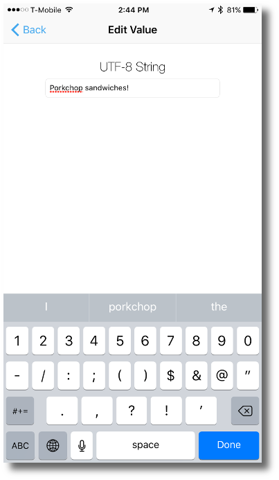

Once written, the new value should be persisted to the characteristic and immediately read back through a response:

[figure not shown]

The second characteristic demonstrates the use of the *SNP_GATT_PROP_WRITE_NORSP* property. A characteristic with this property signifies that the BLE device will not send a response to the host after the write is successful. This is useful when transferring large chunks of data by reducing response overhead. This characteristic also has notification enabled to illustrate the writing of data. Open this characteristic and enable notifications. With notifications enabled, write an arbitrary value to the characteristic:

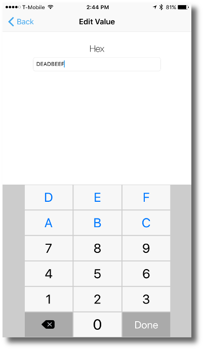

Once written, the new value will show up through the notification stream:

[figure not shown]

# SBL Update

[figure not shown]

*** Note that the default SNP image for all code examples is that of the CC2640R2 LaunchPad SNP. Any hardware configurations using the CC2650 BoosterPack must be explicitly updated to contain the CC2650 BoosterPack SNP image. ***

The console screen will print the status of the firmware update as well as signal when the update has finished. At the end of the update the status of the update will be printed over the serial port and the MSP432 will reboot itself:

[figure not shown]